# A WZA vignette

Tom Booker

15/06/2021

In this RMarkdown, I outline application of the Weighted-Z Analysis (WZA) to simulated data. I’ll give a brief description of the WZA and the simulations then start analysing some data.

# *The WZA*

Genotype-environment association (GEA) analysis is a population genetic analysis that aims to identify genomic regions subject to local adaptation. The idea is that spatially divergent selection will lead to correlation beween allele frequencies and local environmental conditions for some sites in the genome. In a basic GEA analyses, you move along the genome looking at each marker for which you have an allele frequency estimate. For each marker you calculate the correlation between allele freqeuncy and environment. Since closely linked sites may similar evoltuionary histories, combining information across closely linked sites may increase the power of GEA analyses and help identify genomic regions subject to local adaptation.

We propose the Weighted-Z Analysis (the WZA) as a way to combine information in a GEA analysis. We calculate a WZA score for genomic window $k$ with the following:
$$Z_{W,k} = \frac {\sum\limits_{i=1}^n \overline{p_i} (1-\overline{p_i})z_i}{\sqrt{ \sum\limits_{i=1}^n (\overline{p_i}(1-\overline{p_i}))^2} }$$
where $n$ is the number of markers in a focal region, $\overline(p_i)$ is average ferquncy of the minor allele across populations for the $i^{th}$ SNP and $z_i$ is the standard normal deviate calculated from the one-sided $p$-value for the $i^{th}$ SNP.

## *Simulating local adaptation*

Here I re-analyse simulation data from one simulation to demonstrate how to apply the WZA to real data.

Check the pre-print for full simulation details; but briefly, I simulated a meta-population evolving under local adaptation via stabilising selection. The meta-population was a 2D stepping-stone population that had environmental heterogeneity that looked like this:

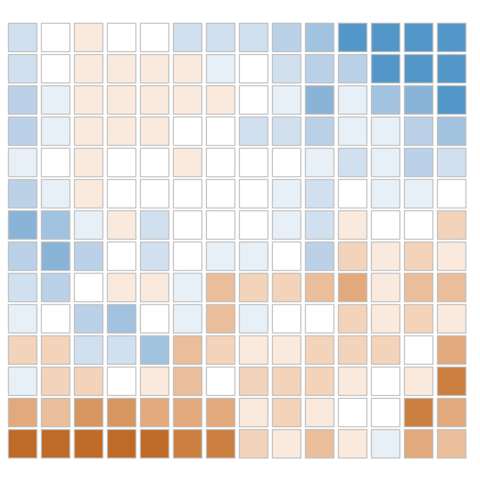

The colours indicate the phenotypic optima of each deme. Populations adapted to their phenotypic optima quite nicely. Here’s a plot showing that adaptation:

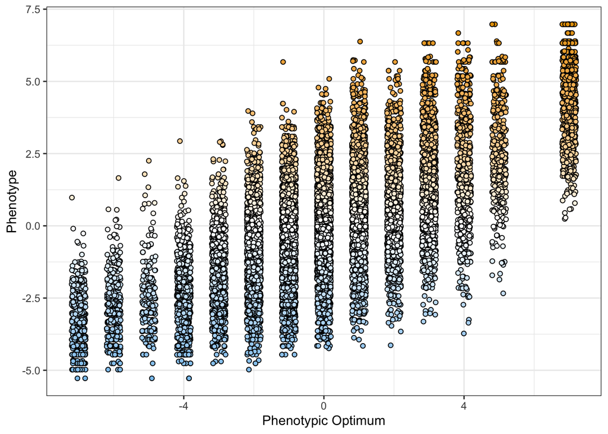

*The colours in this plot are just for show*

In the following, I’ll use the WZA to try and identify the genes that gave rise to this pattern of local adaptation.

## *Performing GEA using the WZA*

From my simulation, I estiamted allele frequencies for 40 demes across the meta-population shown above. I estimated allele freuqnecy in each deme by sampling 50 individuals (i.e. 2,000 individuals in total were sampled). *(I like the word ‘deme’, but some call them populations)*

### Read in the environmental data

The 40 demes had a range of phenotypic optima. Let’s read that data in and take a look:

```r
# Read in the environments
optima <- read.csv("environments.1_0.5_192.alleleFreqs.csv", header = F)

# convert to a numeric vector
optima <- as.numeric(optima[1,])

# inspect the vector to make sure:
optima
```

```
##  [1] -4  3 -3  0  2  1 -1 -1 -1  0  0 -1  0  0 -1 -3  0  1 -2 -1  1  0  0  2 -2
## [26] -1 -2  1  1  0  2  5 -2  0  2  3  7  7 -3  3
```

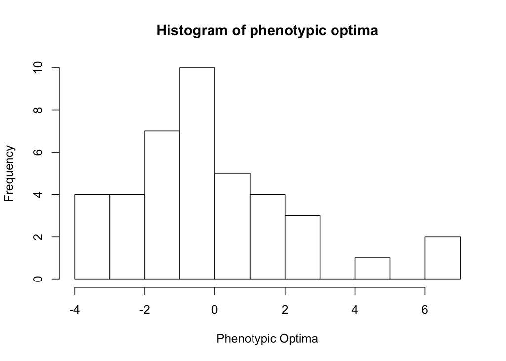

```r
# plot the distribution of values:
hist(optima,
     breaks  = 10,
     main = "Histogram of phenotypic optima",
     xlab = "Phenotypic Optima")
```

Of course, we are working with simulation data so we know the exact phenotypic optima of each deme. That’s not likely to be case in the real world, in the real world we’d have some environmental variable like ‘mean annual temperature’ or ‘relative humidity index’ instead. We’ll treat the phenotypic optima as if they were some measured variable.

### Read in and process the genetic data

Now I’ll read in the genetic data. This step assumes that you have a set of allele frequencies estimated for many biallelic SNPs across the genome of your populations of interest. The file format I’m using is not a standard format (I’m not sure that there is a standard format for such analyses).

The genetic data are stored as a headerless CSV file with the following columns:

1. **Chromosome ID** - this is only here for reference with downstream analyses. If you don’t care about chromosome ust make sure this column has something in it.
2. **Position** - this variable indicates the position of each SNP in the genome.
3. **Window ID** - this is vitally important. This columns is used to determine which SNPs go with which. This could be gene IDs or the coordinates of an analysis window.

Columns 4 to $n+3$ are the allele frequency estimates for each of the $n$ demes sampled.

*Note* that the order of the demes in the CSV files has to match the order of the environments in the environments vector!

```r
# read in the data
all_data <- read.csv("1_0.5_192.alleleFreqs.csv", header = F)


# Let's split the data so that we have an allele freq. dataframe and a dataframe with SNP info
snps_all <- all_data[,1:3]
# Let's put some names on the data to make things easier downstream
names(snps_all) <- c("CHROM","POS","GENE")

# let's take a look at the data, there should be SNPs in gene0 on chromosome 1
str(snps_all)
```

```
## 'data.frame':    66421 obs. of  3 variables:
##  $ CHROM: Factor w/ 5 levels "chr1","chr2",..: 1 1 1 1 1 1 1 1 1 1 ...
##  $ POS  : int  70 90 218 254 329 632 1056 1085 1370 1493 ...
##  $ GENE : Factor w/ 1000 levels "gene0","gene1",..: 1 1 1 1 1 1 1 1 1 1 ...
```

```r
# There's information on 66421 SNPs across the genome

# extract frequency data for each SNP
freqs_all <- all_data[,4:43] # There are 40 demes in the dataset, so columns 4 to 43 represent all the demes

# take a look at the freuqency for the first SNP
as.numeric(freqs_all[1,])
```

```
##  [1] 0.00 0.00 0.00 0.02 0.00 0.00 0.00 0.00 0.00 0.00 0.00 0.00 0.00 0.00 0.00
## [16] 0.00 0.00 0.00 0.07 0.07 0.00 0.00 0.01 0.01 0.00 0.00 0.00 0.00 0.00 0.00
## [31] 0.01 0.00 0.00 0.02 0.00 0.00 0.00 0.00 0.00 0.00
```

```r
# As you can see, most SNPs are at a low minor allele frequency - we remove the low frequency ones before applying the WZA.

# The first thing we'll do is calculate the average allele frequency across populations for each SNP and add it to the SNP info dataframe
snps_all$p_bar <- apply(freqs_all, 1, mean)
snps_all$q_bar <- 1 - snps_all$p_bar

# take the minimum to get the MAF
snps_all$MAF <- pmin(snps_all$p_bar, snps_all$q_bar)

# now we'll apply the MAF filter to the data
snps <- snps_all[snps_all$MAF >= 0.05, ]
freqs <- freqs_all[snps_all$MAF >= 0.05, ]

str(snps)
```

```
## 'data.frame':    23324 obs. of  6 variables:
##  $ CHROM: Factor w/ 5 levels "chr1","chr2",..: 1 1 1 1 1 1 1 1 1 1 ...
##  $ POS  : int  90 254 329 632 1056 1792 2313 2527 3108 3902 ...
##  $ GENE : Factor w/ 1000 levels "gene0","gene1",..: 1 1 1 1 1 1 1 1 1 1 ...
##  $ p_bar: num  0.128 0.36 0.462 0.424 0.298 ...
##  $ q_bar: num  0.872 0.64 0.538 0.576 0.702 ...
##  $ MAF  : num  0.128 0.36 0.462 0.424 0.298 ...
```

```r
# Now we only have 23,324 SNPs in the dataset
```